# Marine Math Bipartite Network

Carrie Diaz Eaton and Sarah Neitzel

5/23/2022

# 1 Overview of Checkpoint

We are going to explore methods for analyzing bipartite networks for interdisciplinary teachign practice. We will use a data set gathered in Fall 2017, where mathematics topics were recorded while in a marine biology class.

## 1.1 Relevant Documentation

- [bipartite](https://cran.r-project.org/web/packages/bipartite/bipartite.pdf)
- frame2webs
- plotweb
- visweb
- [plotpac](https://www.rdocumentation.org/packages/bipartite/versions/2.16/topics/plotPAC)
- RColorBrewer

## 1.2 Checking and Installing Packages

Identifying any packages needed for analysis. Check and then load only what we need.

Figure out which of these packages is already installed

```r
# Store all installed packages
ya_installed <- library()$results[,1]

# Check whether required packages are already installed and grab only those that still need installation
need_install<-my_packages[!(my_packages %in% ya_installed)]

#install required packages
lapply({need_install}, install.packages, character.only = TRUE)
```

```
## list()
```

Now, load only unloaded packages

```r
# Store all installed packages
ya_loaded <- (.packages())

# Check whether required packages are already installed and grab only those that still need installation
need_load<-my_packages[!(my_packages %in% ya_loaded)]

# Load required packages
lapply(need_load, require, character.only = TRUE)
```

[output not shown]

[output not shown]

```
##  For latest changes see versionlog in ?"bipartite-package". For citation see: citation("bipartite").
##  Have a nice time plotting and analysing two-mode networks.
```

```
## [[1]]
## [1] TRUE
##
## [[2]]
## [1] TRUE
```

## 1.3 Data Handling

Clean as necessary.  
Read in as a graph object.

### 1.3.1 Read in Data

Read in the marinemath.csv file and call it mmt.

```r
mmt<-read.csv("marinemath.csv")
```

Take a peak inside mmt.

```r
head(mmt)
```

```
##   X MathItem MarineItem          MarineName          MathName   webID
## 1 1        1          1     dichotomous key     decision tree Mar Bio
## 2 2        2          2 experimental design statistical power Mar Bio
## 3 3        3          3  performance curves             slope Mar Bio
## 4 4        4          3  performance curves           max/min Mar Bio
## 5 5        5          3  performance curves            limits Mar Bio
## 6 6        6          4                tide            vector Mar Bio
```

```r
str(mmt)
```

```
## 'data.frame':    111 obs. of  6 variables:
##  $ X         : int  1 2 3 4 5 6 7 8 9 10 ...
##  $ MathItem  : int  1 2 3 4 5 6 6 7 7 8 ...
##  $ MarineItem: int  1 2 3 3 3 4 5 6 4 4 ...
##  $ MarineName: chr  "dichotomous key" "experimental design" "performance curves" "performance curves" ...
##  $ MathName  : chr  "decision tree" "statistical power" "slope" "max/min" ...
##  $ webID     : chr  "Mar Bio" "Mar Bio" "Mar Bio" "Mar Bio" ...
```

# 2 Analyzing Bipartite Graphs

## 2.1 Structuring the bipartite graph object

To convert the data frame into a graph object, use frame2webs.

```r
#selects columns of interest
mmweb_mathlow<-frame2webs(mmt, varnames = c("MathName", "MarineName", "webID"), type.out = "list", emptylist = TRUE)
```

## 2.2 Visualizing Bipartite Networks

### 2.2.1 Plotting network interactions between two node types

Methods other than ‘cca’ do have merit but can lead to issues with edge readability. If your concept data have a logical order, such as starting with concepts introduced early in the semester and then progressing through time, or can be parsed into one using the function ‘order’ or the ‘sequence’ variable in ‘plotweb’, method ‘normal’ can be used to plot the interactions across time or any other ordered variable. Though edge readability can be an issue, ‘normal’ can be useful for considering trends in node size, such as if concepts that introduced earlier are more or less highly connected that ones introduced later. While this case study worked only with data from one classroom, multiple webs can be stacked on top of each other and interlinked using the variable ‘add’ in ‘plotweb’.

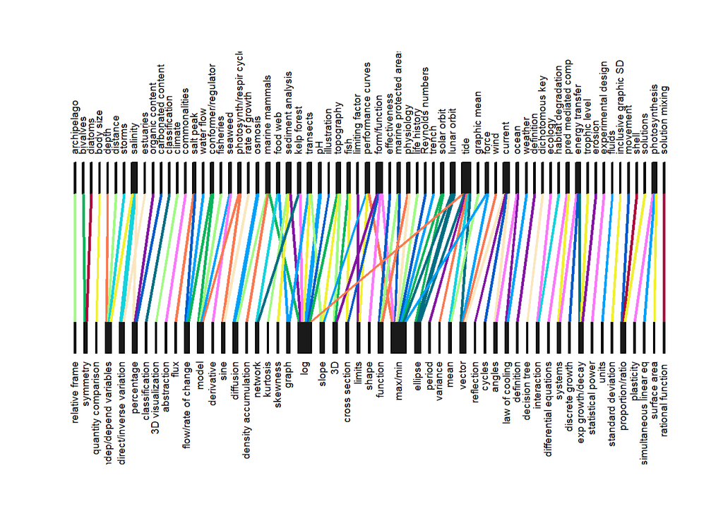

```r
cols1<-c('#006e82', '#8214a0', '#005ac8', '#00a0fa', '#fa78fa', '#14d2dc', '#aa0a3c', '#fa7850', '#0ab45a', '#f0f032', '#a0fa82', '#fae6be')
plotweb(mmweb_mathlow$'Mar Bio', method='cca', labsize=1, x.lim=c(0,3.45), y.lim=c(-0.2,2.2), text.rot=90, col.interaction=cols1, bor.col.interaction=cols1)
```

### 2.2.2 Visualizing the interaction matrix

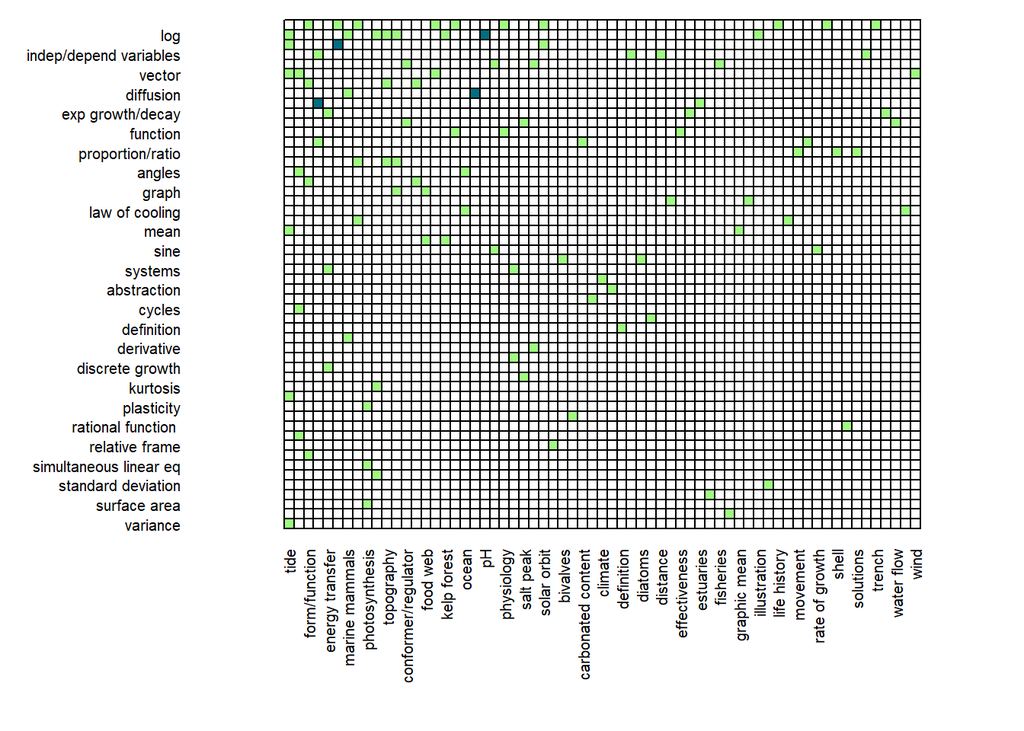

```r
cols2<-c('white', '#a0fa82', '#006e82')
#you can also try other palettes
#cols2 <- brewer.pal(3, "Reds")
visweb(mmweb_mathlow$'Mar Bio', type='nested', labsize=1, plotsize=28, square="defined", def.col=cols2)
```

While ‘nested’ is likely the most helpful grid plot, other types include ‘diagonal’, which can be used to identify compartments or modularity of the network, and ‘none’, which plots the web in the provided order much like the ‘normal’ method for ‘plotweb’

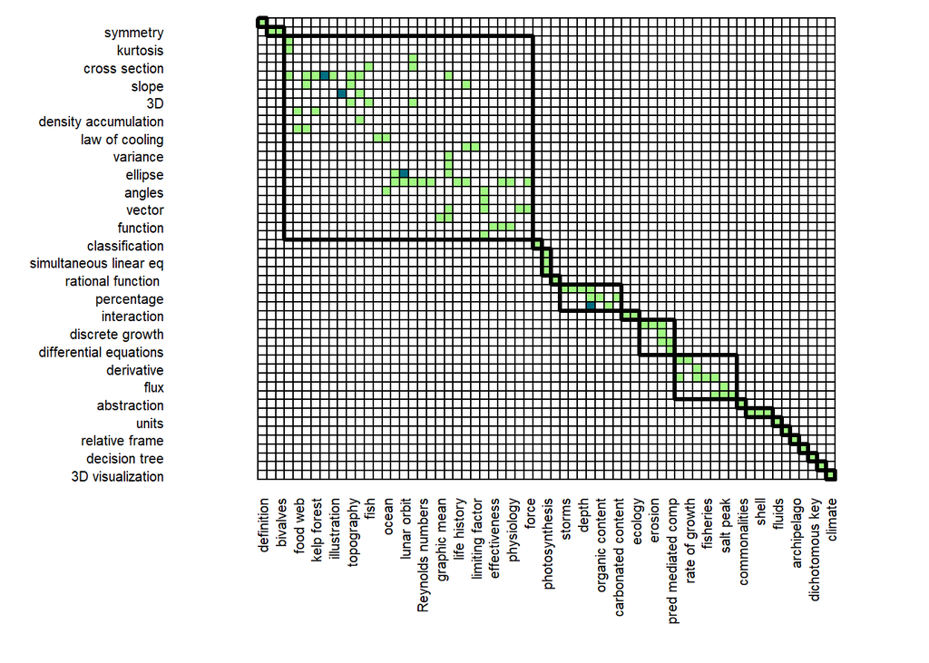

```r
cols2<-c('white', '#a0fa82', '#006e82')
#you can also try other palettes
#cols2 <- brewer.pal(3, "Reds")
visweb(mmweb_mathlow$'Mar Bio', type='diagonal', labsize=1, plotsize=28, square="defined", def.col=cols2)
```

### 2.2.3 Unimodal visualizations

Next we look at a unimodal version of the bimodal data.

The fourth type of visualization is a competition plot done via ‘plotPAC’ (Figure 4). In a biological context, ‘plotPAC’ is used to visualize potential competition with species as circles and shared pollinator/predators as lines. In the context of interdisciplinary work, it can be used to assess the interconnectedness of concepts in one discipline via their connectivity to concepts in the other discipline. It specifically plots the ‘lower’ concepts, hence why the more complete outside concept list - i.e. math - is best assigned as the ‘lower’ level. However, if graphs for both levels are desired, simply create a second web object with ‘frame2webs’ where the level designations are swapped. In the competition plot, items are labelled with their row numbers to conserve space; a quick reference list can be created via the function ‘rownames’.

In the competition plot, circle size corresponds to node size. How much the circle is filled in indicates extent of ‘specialization’ - less fill indicates a ‘generalist’ whereas more fill indicates a ‘specialist’. Lines indicate a shared ‘higher’ level concept between those two ‘lower’ level concepts with the width of the line indicating the strength of the connection.

While the competition plot is also a way of examining nestedness much like the grid plot, it examines nestedness with more of a concept-focus rather than a webwide-focus. This makes it useful for considering novel ways of approaching the ‘lower’ level with the specific goal of enhancing understanding of the ‘upper’ level.

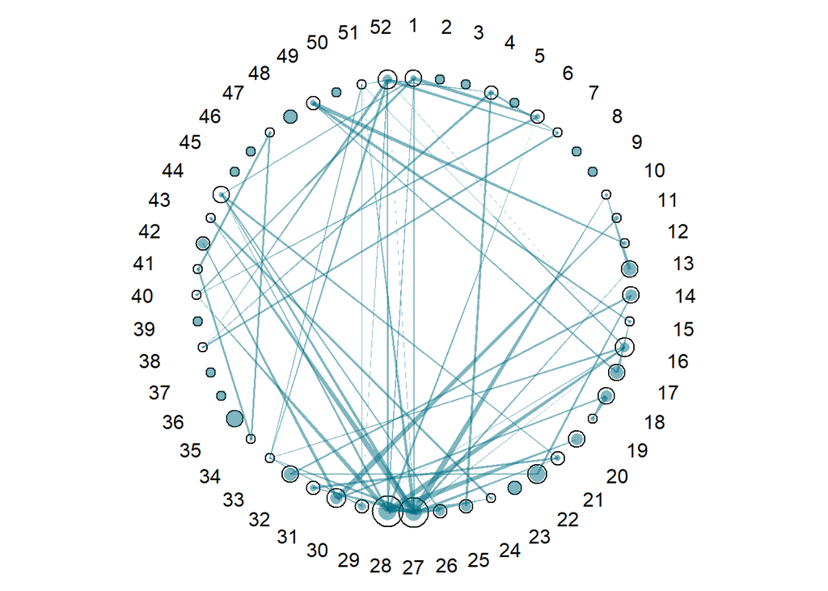

```r
plotPAC(mmweb_mathlow$'Mar Bio', scaling=1.5, fill.col=rgb(0,110/255,130/255,0.5), arrow.col=rgb(0,110/255,130/255,0.5))
```

```r
rownames(mmweb_mathlow$'Mar Bio')
```

```
##  [1] "3D"                       "3D visualization"
##  [3] "abstraction"              "angles"
##  [5] "classification"           "cross section"
##  [7] "cycles"                   "decision tree"
##  [9] "definition"               "density accumulation"
## [11] "derivative"               "differential equations"
## [13] "diffusion"                "direct/inverse variation"
## [15] "discrete growth"          "ellipse"
## [17] "exp growth/decay"         "flow/rate of change"
## [19] "flux"                     "function"
## [21] "graph"                    "indep/depend variables"
## [23] "interaction"              "kurtosis"
## [25] "law of cooling"           "limits"
## [27] "log"                      "max/min"
## [29] "mean"                     "model"
## [31] "network"                  "percentage"
## [33] "period"                   "plasticity"
## [35] "proportion/ratio"         "quantity comparison"
## [37] "rational function "       "reflection"
## [39] "relative frame"           "shape"
## [41] "simultaneous linear eq"   "sine"
## [43] "skewness"                 "slope"
## [45] "standard deviation"       "statistical power"
## [47] "surface area"             "symmetry"
## [49] "systems"                  "units"
## [51] "variance"                 "vector"
```

## 2.3 Quantitive analysis

### 2.3.1 Bipartite summary numbers/indices

Calculate network-level number summaries, similar to unimodal number summaries.

```r
network<-networklevel(mmweb_mathlow$'Mar Bio')
network
```

```
##                       connectance                     web asymmetry
##                      3.136095e-02                      1.111111e-01
##                 links per species            number of compartments
##                      9.059829e-01                      1.900000e+01
##             compartment diversity               cluster coefficient
##                      8.784502e+00                      1.923077e-02
##                        nestedness                              NODF
##                      5.803799e+00                      3.173322e+00
##               weighted nestedness                     weighted NODF
##                               NaN                      2.935995e-02
##    interaction strength asymmetry          specialisation asymmetry
##                      2.040816e-02                     -3.400165e-02
##                   linkage density              weighted connectance
##                      2.795787e+00                      2.389561e-02
##                      Fisher alpha                 Shannon diversity
##                      1.439615e+03                      4.650070e+00
##              interaction evenness      Alatalo interaction evenness
##                      5.722718e-01                      9.802119e-01
##                                H2              number.of.species.HL
##                      7.438479e-02                      6.500000e+01
##              number.of.species.LL mean.number.of.shared.partners.HL
##                      5.200000e+01                      6.153846e-02
## mean.number.of.shared.partners.LL            cluster.coefficient.HL
##                      4.901961e-02                      4.248252e-02
##            cluster.coefficient.LL   weighted.cluster.coefficient.HL
##                      5.272727e-02                      6.174497e-02
##   weighted.cluster.coefficient.LL                  niche.overlap.HL
##                      3.958828e-02                      3.135112e-02
##                  niche.overlap.LL                   togetherness.HL
##                      1.927005e-02                      1.083995e-02
##                   togetherness.LL                        C.score.HL
##                      5.285891e-03                      9.493323e-01
##                        C.score.LL                        V.ratio.HL
##                      9.636066e-01                      6.286765e-01
##                        V.ratio.LL                    discrepancy.HL
##                      1.438211e+00                      9.400000e+01
##                    discrepancy.LL               extinction.slope.HL
##                      8.800000e+01                      1.620184e+00
##               extinction.slope.LL                     robustness.HL
##                      1.386970e+00                      6.165746e-01
##                     robustness.LL     functional.complementarity.HL
##                      5.806385e-01                      8.408587e+01
##     functional.complementarity.LL              partner.diversity.HL
##                      8.315386e+01                      6.272911e-01
##              partner.diversity.LL                     generality.HL
##                      9.486198e-01                      2.199849e+00
##                  vulnerability.LL
##                      3.391725e+00
```

### 2.3.2 Within-group summaries

The function grouplevel() calculates summaries related to each group (marine and math).

```r
group<-grouplevel(mmweb_mathlow$'Mar Bio')
group
```

```
##              number.of.species.HL              number.of.species.LL
##                      65.000000000                      52.000000000
##           mean.number.of.links.HL           mean.number.of.links.LL
##                       2.209090909                       3.427272727
## mean.number.of.shared.partners.HL mean.number.of.shared.partners.LL
##                       0.061538462                       0.049019608
##            cluster.coefficient.HL            cluster.coefficient.LL
##                       0.042482517                       0.052727273
##   weighted.cluster.coefficient.HL   weighted.cluster.coefficient.LL
##                       0.061744966                       0.039588282
##                  niche.overlap.HL                  niche.overlap.LL
##                       0.031351123                       0.019270048
##                   togetherness.HL                   togetherness.LL
##                       0.010839953                       0.005285891
##                        C.score.HL                        C.score.LL
##                       0.949332265                       0.963606607
##                        V.ratio.HL                        V.ratio.LL
##                       0.628676471                       1.438210766
##                    discrepancy.HL                    discrepancy.LL
##                      94.000000000                      88.000000000
##               extinction.slope.HL               extinction.slope.LL
##                       1.608162742                       1.419284274
##                     robustness.HL                     robustness.LL
##                       0.615063751                       0.586090793
##     functional.complementarity.HL     functional.complementarity.LL
##                      84.085870630                      83.153864438
##              partner.diversity.HL              partner.diversity.LL
##                       0.627291110                       0.948619766
##                     generality.HL                  vulnerability.LL
##                       2.199848666                       3.391725096
```

### 2.3.3 Node-level summaries

The function specieslevel() calculates summaries related to each node.

```r
species<-specieslevel(mmweb_mathlow$'Mar Bio')
species$'higher level'['salinity',]
```

```
##          degree normalised.degree species.strength interaction.push.pull
## salinity      3        0.05769231             1.25            0.08333333
##          nestedrank       PDI resource.range species.specificity.index
## salinity   0.046875 0.9803922      0.9607843                 0.6022832
##                PSI node.specialisation.index.NSI betweenness
## salinity 0.4791667                             1  0.02226721
##          weighted.betweenness  closeness weighted.closeness Fisher.alpha
## salinity           0.02210352 0.01197445                 NA     5.452556
##          partner.diversity effective.partners proportional.generality
## salinity          1.039721           2.828427              0.06982738
##          proportional.similarity         d
## salinity              0.09090909 0.5468019
```

```r
species$'lower level'['max/min',]
```

```
##         degree normalised.degree species.strength interaction.push.pull
## max/min     10         0.1538462         5.916667             0.4916667
##         nestedrank      PDI species.specificity.index resource.range PSI
## max/min          0 0.859375                  0.293151       0.859375   1
##         node.specialisation.index.NSI betweenness weighted.betweenness
## max/min                      1.909091   0.1681911            0.1648882
##         closeness weighted.closeness Fisher.alpha partner.diversity
## max/min 0.0465374         0.02500332   2147483653          2.302585
##         effective.partners proportional.similarity proportional.generality
## max/min                 10               0.1909091               0.1790315
##                d
## max/min 0.493227
```

### 2.3.4 Degree Distributions

Generate degree distribution for each (compare and contrast)

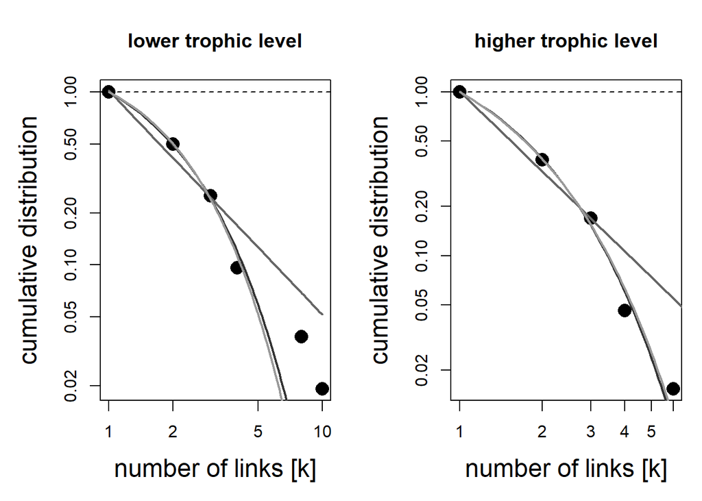

```
## $`lower level dd fits`
##                       Estimate Std. Error     Pr(>|t|)        R2       AIC
## exponential          0.7085502 0.03158068 2.336817e-05 0.9989264 -25.18357
## power law            1.2948040 0.13601442 6.798027e-04 0.9906499 -12.96906
## truncated power law -0.1711254 0.35544745 6.631414e-01 0.9991369 -23.57891
##
## $`higher level dd fits`
##                       Estimate Std. Error     Pr(>|t|)        R2       AIC
## exponential         0.93706565 0.02694538 5.227839e-05 0.9995972 -25.55936
## power law           1.62317729 0.16531106 2.245408e-03 0.9943229 -11.67721
## truncated power law 0.09356115 0.33403345 8.057167e-01 0.9996115 -23.75589
```

```r
degreedistr(mmweb_mathlow$'Mar Bio', plot.it=TRUE, pure.call=TRUE, silent=TRUE, level="both")
```